# Gsynth implementation

### 6. Only Germany

- Filter countries that have strong shocks of unemployment -> YES https://data.worldbank.org/indicator/SL.UEM.TOTL.NE.ZS?locations=DE-ES-GR-PL-NL-PT-LU-CZ-HU
- Filter regions -> YES
- 60km buffer arround each city center
- Filter regions with high unemployment rates that are not compatiable if I am using fixed effects by region. -> YES

```r
n3_dta <- main_dta %>%

  # filter(!geo %in% c(
  #   "DEA22", "DEB35", "DE713", # not good synth C.
  #   "DEA55", "DEA1F", # Not paralel trends
  #   "DEA14", "DE116", "DEE02", "DE714", "DE135"
  # )) %>%
  # filter(!geo %in% c(
  #   "DEA22", "DEB35", "DE713", # not good synth C.
  #   "DEA55", "DEA1F", # Not paralel trends
  #   "DE714", "DEA15", "DEE02",
  #   "DE116", "DE135", "DEA18",
  #   "DE115", "DEA53"
  #   #    "DE116", "DEE02", "DE714", "DE135" # "DEA14",
  # )) %>%
  # filter(geo != "DE711") %>%

  filter(treated_uz | contr_restr_60km) %>%

  filter(country == "DE") %>%

  # filter(!(country %in% c("EL", "ES", "PT"))) %>% #,"PL", "TR")))
  # filter(!(geo %in% not_optimal_treated)) %>%
  group_by(geo) %>%
  filter(
    mean(gdp_eur_hab, na.rm = TRUE) < 75000,
    mean(gdp_eur_hab, na.rm = TRUE) > 15000
  ) %>%
  ungroup()

# Minimum pop density in sample and in treated
n3_dta$pop_km2 %>% summary()
```

```
   Min. 1st Qu.  Median    Mean 3rd Qu.    Max.    NA's
   36.3   122.2   255.5   643.0  1014.9  3405.9     275
```

```r
n3_dta[n3_dta$treated_uz == TRUE, ]$pop_km2 %>% summary()
```

```
   Min. 1st Qu.  Median    Mean 3rd Qu.    Max.    NA's
  176.0   486.7  1201.1  1234.0  1714.7  3405.9      59
```

```r
n3_dta <- n3_dta %>%
  filter(pop_km2 > 100) #avoid rural areas

out_n2 <- gsynth(gdp_eur_hab ~ is_announced_3y, #+ pop_km2 + pop_total,
               data = n3_dta,
               index = c("geo","time"),
               na.rm = TRUE, # remove NA
               force = "time", # unit or time fixed effects or both?
               # CV = TRUE,
               r = c(0,4), # an integer specifying the number of factors. If CV = TRUE, the cross validation procedure will select the optimal number of factors from r to 5.
               se = TRUE,
               EM = TRUE, # Gobillon and Magnac (takes a lot of time)
               inference = "parametric",
               # estimator = "mc",
               nboots = 300,  #500
               parallel = TRUE, cores = 5, # if do parallel and how many cores
               min.T0 = 7) # Has to be larger than r.max+1
```

```
Some treated units has too few pre-treatment periods.
They will be automatically removed.
Parallel computing ...
Cross-validating ...

 r = 0; sigma2 = 141474698.00156; IC = 18.76763; MSPE = 106092284.49975
 r = 1; sigma2 = 3754686.50447; IC = 15.70230; MSPE = 2970066.50745
 r = 2; sigma2 = 1374908.16316; IC = 15.25031; MSPE = 2629556.87065*
 r = 3; sigma2 = 1015008.05739; IC = 15.48827; MSPE = 6935815.39504
 r = 4; sigma2 = 791081.44796; IC = 15.76932; MSPE = 8688732.92411

 r* = 2


Bootstrapping ...

list of removed treated units: DEA22 DEA2D DED51
```

```r
out_n2 %>% print()
```

```
Call:
gsynth.formula(formula = gdp_eur_hab ~ is_announced_3y, data = n3_dta,
    na.rm = TRUE, index = c("geo", "time"), force = "time",
    r = c(0, 4), EM = TRUE, se = TRUE, nboots = 300, inference = "parametric",
    parallel = TRUE, cores = 5, min.T0 = 7)

Average Treatment Effect on the Treated:
 ATT.avg  S.E. CI.lower CI.upper p.value
   35.47 300.8   -488.9    687.2     0.8

   ~ by Period (including Pre-treatment Periods):
        ATT  S.E. CI.lower CI.upper  p.value n.Treated
-6   193.75 181.8  -156.26   543.83 0.253333         0
-5    90.08 173.2  -215.91   476.54 0.440000         0
-4   -35.93 179.3  -328.32   351.12 0.993333         0
-3  -216.16 200.2  -626.97   154.10 0.226667         0
-2    38.58 198.9  -289.09   489.82 0.666667         0
-1   153.94 186.2  -148.85   542.60 0.260000         0
0   -174.89 222.9  -533.13   280.24 0.586667         0
1    107.61 350.9  -553.29   907.06 0.453333        21
2     47.77 365.1  -591.19   733.67 0.800000        21
3    335.03 387.3  -189.56  1301.48 0.146667        21
4    153.77 415.8  -450.79  1213.93 0.400000        21
5    458.17 399.0  -143.73  1394.46 0.093333        21
6    625.14 428.4   -54.38  1737.25 0.066667        20
7   -165.95 435.8  -901.95   817.14 0.953333        19
8    -64.43 461.6 -1034.44   694.42 0.846667        17
9   -756.77 502.0 -1942.60    81.38 0.060000        16
10 -2316.99 603.6 -4838.70 -2408.52 0.000000        10
11  3537.82 976.3  1718.41  5470.00 0.006667         3
```

```r
out_n2$Nco
```

```
[1] 63
```

```r
out_n2$Ntr
```

```
[1] 21
```

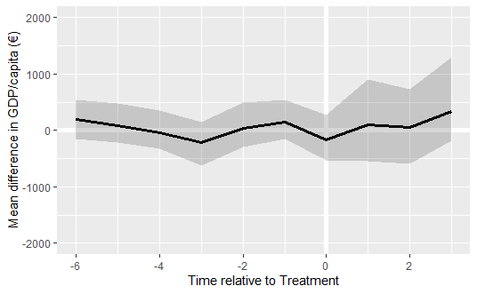

```r
plot(out_n2, ylim = c(-2000, 2000),
     xlim = c(-8, 3),
     main = "",
     ylab = "Mean difference in GDP/capita (€)")
```

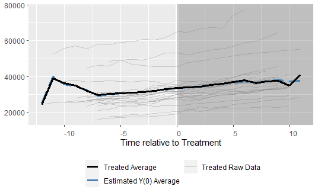

```r
# plot all data:
plot(out_n2, type = "counterfactual",
     raw = "all", main = "") # Why the final dip
```

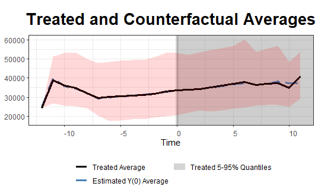

```r
# We can also add two 5 to 95% quantile bands of the treated and control outcomes as references to make sure the estimated counterfactuals are not results of severe extrapolations.

plot(out_n2, type = "counterfactual",
     raw = "band", xlab = "Time",
     # ylim = c(-5,35),
     theme.bw = TRUE)
```

```
DEA22 not in the treatment groupDEA2D not in the treatment groupDED51 not in the treatment group
```

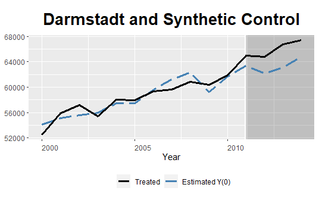

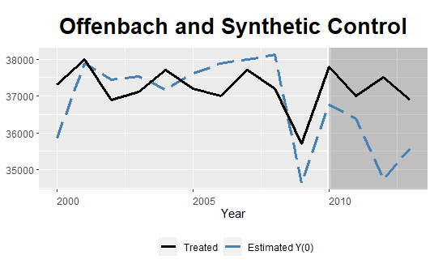

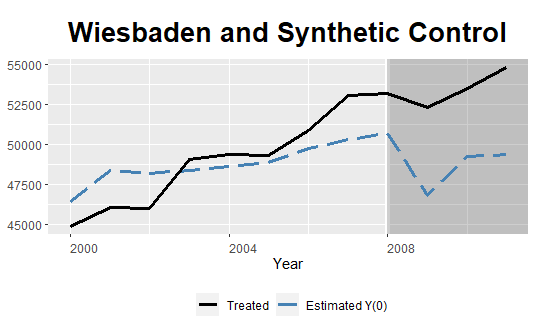

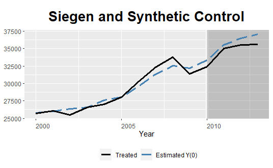

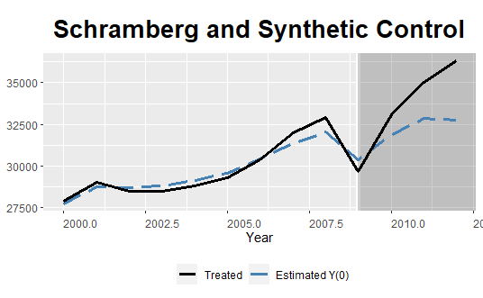

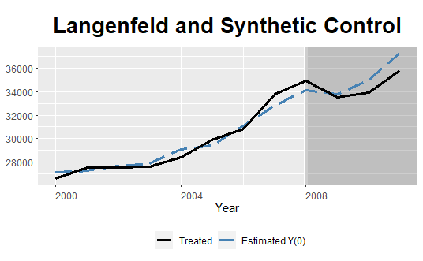

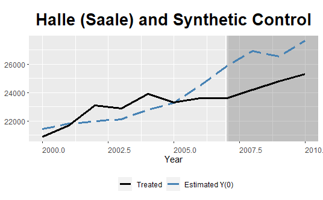

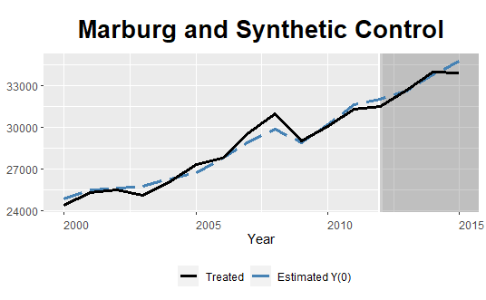

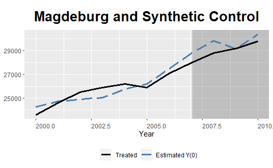

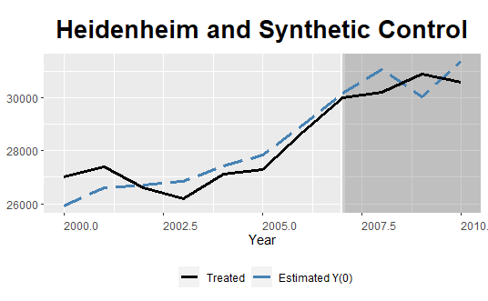

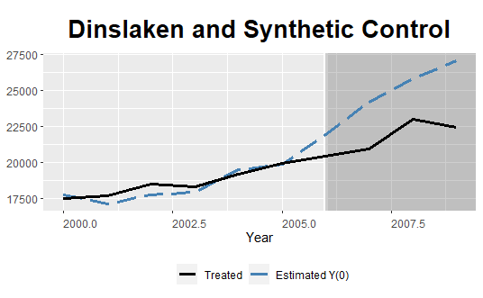

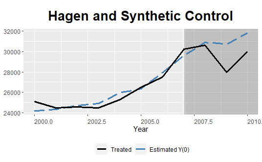

[9 more figures not shown]

```r
for (i in n3_dta[n3_dta$treated_uz == TRUE, ]$geo %>% unique()){
  plot(out_n2, type = "counterfactual", id = i,
       xlim = c(2000, n3_dta[n3_dta$geo == i,
                                           ]$year_announced[1]-1),
       main = paste0(n3_dta[n3_dta$geo == i,]$LEZ[1],
                       " and Synthetic Control"),
       sub = "Pre-intervention placebo of 3 years",
       xlab = "Year")
}
```

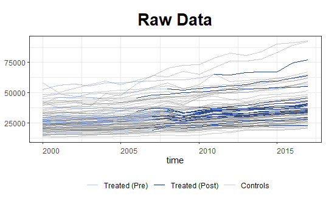

```r
plot(out_n2, type = "raw", theme.bw = TRUE)
```

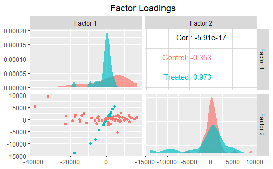

```r
plot(out_n2, type = "loadings")
```

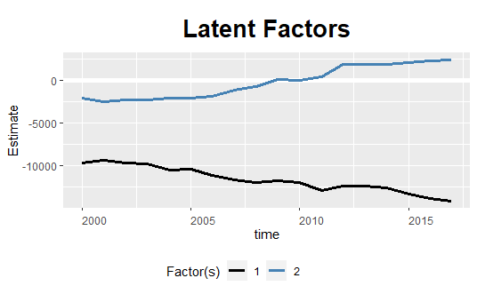

```r
plot(out_n2, type = "factors")
```

```r
out_n2$lambda.tr
```

```
               r1          r2
DE113   -746.8669   -945.7840
DE115  -1274.0982  -1423.3751
DE116    983.2244   1185.6297
DE11C    459.6646    548.2982
DE135   -141.5321   -318.8605
DE711 -17754.4956 -13861.8378
DE713  -4109.7976  -4417.8459
DE714  -8944.3921 -10093.7150
DE724   1621.9974    970.8447
DEA14  -1586.2250  -2135.2066
DEA15   1914.5127   2084.0447
DEA18    526.8945    559.7611
DEA1C   -271.1899   -133.3494
DEA1F   3182.3066   4318.2244
DEA53   1027.5185   1355.9741
DEA55   4435.7284   5486.1453
DEA5A    336.0980    542.3702
DEB35  -6129.2180  -8425.5536
DEE02   2283.1580   2760.9100
DEE03   1111.9194   1359.0567
DEG01   -152.5476   -273.1229
```

### 8. New 4. but with more controls and less cities :/

```r
n3_dta <- main_dta %>%

  # filter(!geo %in% c(
  #   "DEA22", "DEB35", "DE713", # not good synth C.
  #   "DEA55", "DEA1F", # Not paralel trends
  #   "DEA14", "DE116", "DEE02", "DE714", "DE135"
  # )) %>%
  filter(!geo %in% c(
    # "DEA22", "DEB35",
    "DE713", # not good synth C.
    "DEA18", "DEA15", "DEA5A", "DEA53", "DEA14",
    "DEA55",
    "DEA1F", # Not paralel trends
    # "DE714",
    "DEE03",
    # "DE116",
    "DE135",
    "DE11C",
    "DE115",
    "DE724",
    "DE113", # Almost correct but not really
    #  "DE116", "DE714", "DE135" # "DEA14",
    "DEE02",
    "DED51" #Liepzing, impossible to do pre tr. placebo.
  )) %>%
  filter(geo != "DE711") %>%

  filter(treated_uz | contr_restr_60km) %>%
  # filter(country == "DE") %>%
  filter(country %in% c("DE",
                        "NL", "BE", "AT",
                        "SE", "NO", "FI"
                        )) %>%
  # filter(!(country %in% c("EL", "ES", "PT"))) %>% #,"PL", "TR")))
  # filter(!(geo %in% not_optimal_treated)) %>%
  group_by(geo) %>%
  filter(
    mean(gdp_eur_hab, na.rm = TRUE) < 45000,
    mean(gdp_eur_hab, na.rm = TRUE) > 15000
  ) %>%
  ungroup()

# Minimum pop density in sample and in treated
n3_dta$pop_km2 %>% summary()
n3_dta[n3_dta$treated_uz == TRUE, ]$pop_km2 %>% summary()

n3_dta <- n3_dta %>%
  filter(pop_km2 > 100) #avoid rural areas

out_n2 <- gsynth(gdp_eur_hab ~ is_announced + pop_km2 + pop_total,
               data = n3_dta,
               index = c("geo","time"),
               na.rm = TRUE, # remove NA
               force = "time", # unit or time fixed effects or both?
               # CV = TRUE,
               r = c(0,4), # an integer specifying the number of factors. If CV = TRUE, the cross validation procedure will select the optimal number of factors from r to 5.
               se = TRUE,
               EM = TRUE, # Gobillon and Magnac (takes a lot of time)
               inference = "parametric",
               # estimator = "mc",
               nboots = 300,  #500
               parallel = TRUE, cores = 5, # if do parallel and how many cores
               min.T0 = 7) # Has to be larger than r.max+1

out_n2 %>% print()
out_n2$Nco
out_n2$Ntr

plot(out_n2, ylim = c(-2000, 2000),
     # xlim = c(-8, 3),
     main = "",
     ylab = "Mean difference in GDP/capita (€)")

# plot all data:
plot(out_n2, type = "counterfactual",
     raw = "all", main = "") # Why the final dip


# We can also add two 5 to 95% quantile bands of the treated and control outcomes as references to make sure the estimated counterfactuals are not results of severe extrapolations.

plot(out_n2, type = "counterfactual",
     raw = "band", xlab = "Time",
     # ylim = c(-5,35),
     theme.bw = TRUE)

for (i in n3_dta[n3_dta$treated_uz == TRUE, ]$geo %>% unique()){
  plot(out_n2, type = "counterfactual", id = i,
       # xlim = c(2000, n3_dta[n3_dta$geo == i,
       #                                     ]$year_announced[1]-1),
       main = paste0( i , " ",
                      n3_dta[n3_dta$geo == i,]$LEZ[1],
                       " and Synthetic Control"),
       sub = "Pre-intervention placebo of 3 years",
       xlab = "Year")
}

plot(out_n2, type = "raw", theme.bw = TRUE)

plot(out_n2, type = "loadings")
plot(out_n2, type = "factors")
out_n2$lambda.tr
```

```r
plot(2000:2017, out_n2$xi)

out_n2$alpha.tr

out_n2$alpha.co

out_n2$validX #¿?

out_n2$est.att

# out_n2$est.ind # Inference for each treated unit!!!
```

#### Maps

```r
# Know the donor pool of each treated:
weights_result <- out_n2$wgt.implied %>%
  as_tibble(rownames = "NUTS_ID")

donor_pool <- nuts_treated %>%
  filter(LEVL_CODE == 2) %>%
  left_join(weights_result) %>%
  filter(!is.na(DE30))

donor_pool %>% as.data.frame() %>%
  select(NUTS_ID, DE30, DE92, DE21) %>%
  arrange(desc(DE30))


leaflet() %>% addTiles() %>%
  addPolygons(data = donor_pool, weight = 0.5, color = "black",
              fillColor = ~colorQuantile("RdYlGn",
                      donor_pool$DE92)(donor_pool$DE92),
              popup = paste0(
                "<b>", donor_pool$NUTS_ID, "</b> <br/>",
                "<b> Weight Berlin </b>", donor_pool$DE30, "<br/>",
                "<b> Weight Hannover </b>", donor_pool$DE92, "<br/>")
              )
```

### 7. Inverse Synthetic control

- I do innaguration as announcment does not seem to have created any sizable effect.

> ¿really?
- Hard to do with gsynth given it does not work very good with only one treated
- ¿How to test for a good synthetic “treated”?
  - pre-intervention placebo: Restrict the “treated” pool to teated units that applied the mesure that year and set the date 2 or 3 years before the actual implementation of the measure, there should be no effect as both are not affected by the policy
  - Use each treated as a fake control and perform synthetic treated method on it, look at the effects and if the real control region has an “specially big” effect comparing with the fake controls.

##### Placebo 2010

> Without cities that had actual reductions

```r
non_treated <- c("DEB21", "DEB3A",
                 "DE262", "DE263",
                 # Close to Hanburg (NORTH)
                 "DEF01", "DEF02", "DEF03",
                 "DE273", "DE222", "DE233",
                 # Close to big city (Nürnberg)
                 "DE255", "DE253", "DE252", "DE251",
                 "DE241", "DE242", "DE243", "DE244",

                 "DE945",
                 "DE731", "DE402",
                 "DED41")

fake_tr_dta <- main_dta %>%
  # treated (fake controls) or "non-treated" (fake treated)
  filter(treated_uz | geo %in% non_treated) %>%
  # Remove all "treated" NUTS3 regions that are not representative of their cities
  filter( !(geo %in% not_optimal_treated))

# Select placebo year of announcment / or implementation
year_start_policy <- 2010

fake_tr_dta <- fake_tr_dta %>%
  # filter those regions that have not a good synthetic treated
  ## 2010
  filter(!geo %in% c("DE263", "DE262", "DE731",
                     "DEB21",
                     # CLOSE TO NUREMBERG
                     "DE255", "DE253", "DE252", "DE251",
                     "DE241", "DE242", "DE243", # "DE244",

                     "DE273", "DE222", "DE233",
                     "DEB3A",
                     "DEF01", "DEF02", "DEF03",
                     "DE945")) %>%
  # Filter treated that have a confounding factor (Magdeburg)
  filter(geo != "DEE03")

fake_tr_dta <- fake_tr_dta %>%
  # take all cities that announced that year and the control
  filter(year_announced ==
           year_start_policy | is.na(year_announced)) %>%
  # Transform treated into controls and controls into treated
  mutate(year_announced = ifelse(is.na(year_stage1),
                              year_start_policy, NA),
         is_treated = case_when(
           is.na(year_announced) ~ 0, # Control, never inagurated
           time < year_announced ~ 0, # Before the inaguration
           TRUE ~ 1 # if neither, then its after
         ),
         is_treated_3y = case_when(
           is.na(year_announced) ~ 0, # Control, never inagurated
           time < year_announced - 3  ~ 0, # Before the inaguration
           TRUE ~ 1 # if neither, then its after
         ),
         is_treated_4y = case_when(
           is.na(year_announced) ~ 0, # Control, never inagurated
           time < year_announced - 4  ~ 0, # Before the inaguration
           TRUE ~ 1 # if neither, then its after
         )
         )  #

fake_tr_dta %>%
  select(time, geo, year_announced, is_treated, is_treated_4y)

out_n2 <- gsynth(gdp_eur_hab ~ is_treated_4y,
               data = fake_tr_dta,
               index = c("geo","time"),
               na.rm = TRUE, # remove
               force = "time", # unit or time fixed effects or both?
               # CV = TRUE,
               r = c(0, 5), # an integer specifying the number of factors. If CV = TRUE, the cross validation procedure will select the optimal number of factors from r to 5.
               se = TRUE,
               EM = TRUE, # Gobillon and Magnac (takes a lot of time)
               inference = "parametric",
               # estimator = "mc",
               nboots = 200,  #500
               parallel = TRUE, cores = 5, # if do parallel and how many cores
               min.T0 = 6) # Has to be larger than r.max+1

out_n2 %>% print()
print(paste0("Nº `Control` (Treated) = ", out_n2$Nco))
print(paste0("Nº non-treated = ", out_n2$Ntr))

plot(out_n2, xlim = c(-8, 4),
     main = "",
     ylab = "Mean difference in GDP/capita (€)")

# plot all data:
plot(out_n2, type = "counterfactual",
     raw = "all", main="") # Why the final dip


# We can also add two 5 to 95% quantile bands of the treated and control outcomes as references to make sure the estimated counterfactuals are not results of severe extrapolations.

plot(out_n2, type = "counterfactual",
     raw = "band", xlab = "Time",
     # ylim = c(-5,35),
     theme.bw = TRUE)

for (i in fake_tr_dta[!is.na(fake_tr_dta$year_announced), ]$geo %>% unique()){
  if (i %in% out_n2$id.tr){
    plot(out_n2, type = "counterfactual", id = i,
         xlim = c(2000, fake_tr_dta[fake_tr_dta$geo == i,
                                           ]$year_announced[1]-1))
  }
}

plot(out_n2, type = "raw", theme.bw = TRUE)

plot(out_n2, type = "loadings")
plot(out_n2, type = "factors")
```

> Possible to create placebos with bad treated regions (not representative) but impossible to do it without them.

##### Real Inver

```r
fake_tr_dta_real <- fake_tr_dta %>%
  # fake treated that have good synths(prev.step) or real treated
  filter(geo %in% out_n2$id.tr | treated_uz )

out_n2 <- gsynth(gdp_eur_hab ~ is_treated,
               data = fake_tr_dta_real,
               index = c("geo","time"),
               na.rm = TRUE, # remove
               force = "time", # unit or time fixed effects or both?
               # CV = TRUE,
               r = c(0, 5), # an integer specifying the number of factors. If CV = TRUE, the cross validation procedure will select the optimal number of factors from r to 5.
               se = TRUE,
               EM = TRUE, # Gobillon and Magnac (takes a lot of time)
               inference = "parametric",
               # estimator = "mc",
               nboots = 200,  #500
               parallel = TRUE, cores = 5, # if do parallel and how many cores
               min.T0 = 7) # Has to be larger than r.max+1
```

```r
out_n2 %>% print()

print(paste0("Nº `Control` (Treated) = ", out_n2$Nco))
print(paste0("Nº non-treated = ", out_n2$Ntr))

# plot(out_n2, main = "Estimated ATE in the non-treated")#, ylim = c(-5000, 2000))

out_n2$est.att %>%
  as_tibble(rownames = "rel_time") %>%
  mutate(
    # This puts 2010 as the year "0"
    rel_time = as.numeric(rel_time)-10,
    # This gives the real ATC as the "treated" are not really treated
    ATT = -ATT, CI.lower = -CI.lower, CI.upper = -CI.upper) %>%
  ggplot(aes(x= rel_time, y = ATT, group = 1)) +
  geom_ribbon(aes(ymin = CI.lower, ymax = CI.upper),
              alpha = 0.2) +
  geom_line(size = 1.5) +
  geom_vline(xintercept = 0) +
  geom_hline(yintercept = 0) +
  labs(
    title = "Estimated ATE in the non-treated",
    x = "Time relative to Announcment",
    y = "GDP per capita (€)"
  )

# # plot all data:
# plot(out_n2, type = "counterfactual",
#      raw = "all", main="")

# We can also add two 5 to 95% quantile bands of the treated and control outcomes as references to make sure the estimated counterfactuals are not results of severe extrapolations.

# plot(out_n2, type = "counterfactual",
#      raw = "band", xlab = "Time",
#      # ylim = c(-5,35),
#      theme.bw = TRUE)

for (i in fake_tr_dta[!is.na(fake_tr_dta$year_announced), ]$geo %>%
     unique()){
  if (i %in% out_n2$id.tr){
    temp <- plot(out_n2, type = "counterfactual", id = i,
         main = paste0("Control and Synthetic T (",i, ")"),
         xlab = "Year",
         ylab = "PIB per capita (€)"
    )
    # print(temp + scale_fill_discrete(limits=c("2", "0.5")))
  }
}

plot(out_n2, type = "raw", theme.bw = TRUE)

plot(out_n2, type = "loadings")
plot(out_n2, type = "factors")
```

> I need to modify the graphs, titles and axis

What is the treated pool?

```r
treated_pool <- out_n2$id.co

names_geo <- main_dta %>%
  # filter(geo %in% treated_pool) %>%
  select(geo, simple_LEZ, nuts_name) %>% unique()

weights_treated_pool <- out_n2$wgt.implied %>%
  as.tibble(rownames = "treated") %>%
  pivot_longer(cols = 2:4, names_to = "control") %>%
  left_join(names_geo[, 1:2], by = c("treated" = "geo")) %>%
  rename(name_treated = simple_LEZ) %>%
  left_join(names_geo, by = c("control" = "geo")) %>%
  rename(name_control = nuts_name) %>%
  mutate(name_control = stringr::str_extract(name_control, "^(.+?),")) %>%
  select(-simple_LEZ)

weights_treated_pool <- weights_treated_pool %>%
  group_by(control) %>%
  mutate(value_std = (value-mean(value))/sd(value)) %>%
  ungroup()

ggplot(data = weights_treated_pool) +
  geom_point(aes(x = name_control, y = value, color = name_treated),
             size = 2) +
  coord_flip() +
  labs(
    y = "Implied Weight",
    x = "Non-treated Region"
  )
```

```r
for (i in fake_tr_dta_real[fake_tr_dta_real$treated_uz == FALSE, ]$geo %>% unique()){
  if (i %in% out_n2$id.tr){
    # print(i)
    plot_i <- out_n2$est.ind[, ,i] %>%
      as.tibble(rownames = "rel_time") %>%
      mutate(rel_time = as.numeric(rel_time)+2000) %>%
      ggplot(aes(x= rel_time, y = -EFF, group = 1)) +
      geom_ribbon(aes(ymin = -CI.lower, ymax = -CI.upper),
                  alpha = 0.3) +
      geom_line() +
      geom_vline(xintercept = 2010) +
      geom_hline(yintercept = 0) +
      labs(
        title = paste0(i, " - " ,fake_tr_dta_real[fake_tr_dta_real$geo == i,]$nuts_name[1]),
        x = "Time relative to Announcment",
        y = "GDP per capita (€)"
      )
    print(plot_i)
  }
}
```

##### Placebo 2011

> With cities that had actual reductions

```r
non_treated <- c("DEB21", "DEB3A",
                 "DE262", "DE263",
                 # Close to Hanburg (NORTH)
                 "DEF01", "DEF02", "DEF03",
                 "DE273", "DE222", "DE233",
                 # Close to big city (Nürnberg)
                 "DE255", "DE253", "DE252", "DE251",
                 "DE241", "DE242", "DE243", "DE244",

                 "DE945",
                 "DE731", "DE402",
                 "DED41")

fake_tr_dta <- main_dta %>%
  # treated (fake controls) or "non-treated" (fake treated)
  filter(treated_uz | geo %in% non_treated) %>%
  # Remove all "treated" NUTS3 regions that are not representative of their cities
  filter( !(geo %in% not_optimal_treated))


# Select placebo year of announcment / or implementation
year_start_policy <- 2011

fake_tr_dta <- fake_tr_dta %>%
# filter those regions that  do have a good synthetic treated
# 2011
filter((geo %in% c("DED41", "DE402", "DEF03")) | treated_uz) %>%   # Filter treated that have a confoundeing factor (Magdeburg)
  filter(geo != "DEE03")

fake_tr_dta <- fake_tr_dta %>%
  # take all cities that announced that year and the control
  filter(year_announced ==
           year_start_policy | is.na(year_announced)) %>%
  # Transform treated into controls and controls into treated
  mutate(year_announced = ifelse(is.na(year_stage1),
                              year_start_policy, NA),
         is_treated = case_when(
           is.na(year_announced) ~ 0, # Control, never inagurated
           time < year_announced ~ 0, # Before the inaguration
           TRUE ~ 1 # if neither, then its after
         ),
         is_treated_3y = case_when(
           is.na(year_announced) ~ 0, # Control, never inagurated
           time < year_announced - 3  ~ 0, # Before the inaguration
           TRUE ~ 1 # if neither, then its after
         ),
         is_treated_4y = case_when(
           is.na(year_announced) ~ 0, # Control, never inagurated
           time < year_announced - 4  ~ 0, # Before the inaguration
           TRUE ~ 1 # if neither, then its after
         )
         )  #

fake_tr_dta %>%
  select(time, geo, year_announced, is_treated, is_treated_3y)

out_n2 <- gsynth(gdp_eur_hab ~ is_treated_4y,
               data = fake_tr_dta,
               index = c("geo","time"),
               na.rm = TRUE, # remove
               force = "time", # unit or time fixed effects or both?
               # CV = TRUE,
               r = c(0, 2), # an integer specifying the number of factors. If CV = TRUE, the cross validation procedure will select the optimal number of factors from r to 5.
               se = TRUE,
               EM = TRUE, # Gobillon and Magnac (takes a lot of time)
               inference = "parametric",
               # estimator = "mc",
               nboots = 200,  #500
               parallel = TRUE, cores = 5, # if do parallel and how many cores
               min.T0 = 6) # Has to be larger than r.max+1

out_n2 %>% print()
print(paste0("Nº `Control` (Treated) = ", out_n2$Nco))
print(paste0("Nº non-treated = ", out_n2$Ntr))

plot(out_n2, xlim = c(-8, 4),
     main = "",
     ylab = "Mean difference in GDP/capita (€)")

# plot all data:
plot(out_n2, type = "counterfactual",
     raw = "all", main="") # Why the final dip


# We can also add two 5 to 95% quantile bands of the treated and control outcomes as references to make sure the estimated counterfactuals are not results of severe extrapolations.

plot(out_n2, type = "counterfactual",
     raw = "band", xlab = "Time",
     # ylim = c(-5,35),
     theme.bw = TRUE)

for (i in fake_tr_dta[!is.na(fake_tr_dta$year_announced), ]$geo %>% unique()){
  if (i %in% out_n2$id.tr){
    # pdf(file=paste0("images/prelim_results/ind_inverse_placebo",
    #               "_",  i, ".pdf"),
    # width = 3.5, height = 2.7)
    plot(out_n2, type = "counterfactual", id = i,
         xlim = c(2000, fake_tr_dta[fake_tr_dta$geo == i,
                                           ]$year_announced[1]-1),
         # main = "",
         xlab = "Year",
         ylab = "PIB per capita (€)"
         )
    # dev.off()
  }
}

plot(out_n2, type = "raw", theme.bw = TRUE)

plot(out_n2, type = "loadings")
plot(out_n2, type = "factors")
```

##### Real Inver

```r
fake_tr_dta_real <- fake_tr_dta %>%
  # fake treated that have good synths(prev.step) or real treated
  filter(geo %in% out_n2$id.tr | treated_uz )

out_n2 <- gsynth(gdp_eur_hab ~ is_treated,
               data = fake_tr_dta_real,
               index = c("geo","time"),
               na.rm = TRUE, # remove
               force = "time", # unit or time fixed effects or both?
               # CV = TRUE,
               r = c(0, 3), # an integer specifying the number of factors. If CV = TRUE, the cross validation procedure will select the optimal number of factors from r to 5.
               se = TRUE,
               EM = TRUE, # Gobillon and Magnac (takes a lot of time)
               inference = "parametric",
               # estimator = "mc",
               nboots = 200,  #500
               parallel = TRUE, cores = 5, # if do parallel and how many cores
               min.T0 = 7) # Has to be larger than r.max+1
```

```r
out_n2 %>% print()

print(paste0("Nº `Control` (Treated) = ", out_n2$Nco))
print(paste0("Nº non-treated = ", out_n2$Ntr))

# plot(out_n2, main = "Estimated ATE in the non-treated")#, ylim = c(-5000, 2000))

out_n2$est.att %>%
  as_tibble(rownames = "rel_time") %>%
  mutate(
    # This puts 2010 as the year "0"
    rel_time = as.numeric(rel_time)-10,
    # This gives the real ATC as the "treated" are not really treated
    ATT = -ATT, CI.lower = -CI.lower, CI.upper = -CI.upper) %>%
  ggplot(aes(x= rel_time, y = ATT, group = 1)) +
  geom_ribbon(aes(ymin = CI.lower, ymax = CI.upper),
              alpha = 0.2) +
  geom_line(size = 1.5) +
  geom_vline(xintercept = 0) +
  geom_hline(yintercept = 0) +
  labs(
    title = "Estimated ATE in the non-treated",
    x = "Time relative to Announcment",
    y = "GDP per capita (€)"
  )

# # plot all data:
# plot(out_n2, type = "counterfactual",
#      raw = "all", main="")

# We can also add two 5 to 95% quantile bands of the treated and control outcomes as references to make sure the estimated counterfactuals are not results of severe extrapolations.

# plot(out_n2, type = "counterfactual",
#      raw = "band", xlab = "Time",
#      # ylim = c(-5,35),
#      theme.bw = TRUE)

for (i in fake_tr_dta[!is.na(fake_tr_dta$year_announced), ]$geo %>%
     unique()){
  if (i %in% out_n2$id.tr){
    # pdf(file=paste0("images/prelim_results/ind_inverse_real",
    #                 "_",  i, ".pdf"),
    #     width = 3.5, height = 2.7)
    temp <- plot(out_n2, type = "counterfactual", id = i,
                 main = "",
                 # main = paste0("Control and Synthetic T (",i, ")"),
                 xlab = "Year",
                 ylab = "PIB per capita (€)"
    )
    # dev.off()
    # print(temp + scale_fill_discrete(limits=c("2", "0.5")))
  }
}

plot(out_n2, type = "raw", theme.bw = TRUE)

plot(out_n2, type = "loadings")
plot(out_n2, type = "factors")
```

> I need to modify the graphs, titles and axis I need to have some sense of what “treatment” I am applyting to this set of controls.

What is the treated pool?

```r
treated_pool <- out_n2$id.co

names_geo <- main_dta %>%
  # filter(geo %in% treated_pool) %>%
  select(geo, simple_LEZ, nuts_name) %>% unique()

weights_treated_pool <- out_n2$wgt.implied %>%
  as.tibble(rownames = "treated") %>%
  pivot_longer(cols = DE402:DEF03, names_to = "control") %>%
  left_join(names_geo[, 1:2], by = c("treated" = "geo")) %>%
  rename(name_treated = simple_LEZ) %>%
  left_join(names_geo, by = c("control" = "geo")) %>%
  rename(name_control = nuts_name) %>%
  mutate(name_control = stringr::str_extract(name_control, "^(.+?),")) %>%
  select(-simple_LEZ)

weights_treated_pool <- weights_treated_pool %>%
  group_by(control) %>%
  mutate(value_std = (value-mean(value))/sd(value)) %>%
  ungroup()

# pdf(file=paste0("images/prelim_results/inverse_2011_weights.pdf"),
#     width = 5.5, height = 2.5)
ggplot(data = weights_treated_pool) +
  geom_point(aes(x = name_control, y = value, color = name_treated),
             size = 3) +
  coord_flip() +
  labs(
    y = "Implied Weight",
    x = "Non-treated region"
  ) +
  scale_color_discrete(name = "Treated Pool")
# dev.off()


# +  geom_text(aes(x = name_control, y = value_std,
#                 label = name_treated, angle = 90),
#             nudge_x = 0.0, nudge_y = -0.3,
#             size = 4, check_overlap = TRUE,)
```

> Cottbus anf Chemniz ae both East german mid sized cities while Lübeck its a very important port city close to Hanburg in West Germany.

```r
for (i in fake_tr_dta_real[fake_tr_dta_real$treated_uz == FALSE, ]$geo %>% unique()){
  if (i %in% out_n2$id.tr){
    # pdf(file=paste0("images/prelim_results/ind_inverse_real_eff",
    #                 "_",  i, ".pdf"),
        # width = 4, height = 2.7)
    plot_i <- out_n2$est.ind[, ,i] %>%
      as.tibble(rownames = "rel_time") %>%
      mutate(rel_time = as.numeric(rel_time)+2000) %>%
      ggplot(aes(x= rel_time, y = -EFF, group = 1)) +
      geom_ribbon(aes(ymin = -CI.lower, ymax = -CI.upper),
                  alpha = 0.2) +
      geom_line(size = 1.5) +
      geom_vline(xintercept = 2010) +
      geom_hline(yintercept = 0) +
      labs(
        title = paste0(i, " - " ,fake_tr_dta_real[fake_tr_dta_real$geo == i,]$nuts_name[1]),
        x = "Year",
        y = "GDP per capita (€)"
      )
    print(plot_i)
    # dev.off()
  }
}
```

### Conclusion pre-tr

- It is possible to create a good synthetic control even with a 60km buffer of every region.
- It NEEDS time fixed effects (because of the finantial crisis)
- Unit fixed effects are very useful and can be controled by restricting the overall values of the outcome. Not having unit fixed effects decreases the credibility of the synthetic method.

## Share of GDP

### Local trade: Retail, transport, accomodation and food

#### pre-treatment placebo (4y)

Do first analysis (look for good pre-treatment placebo):

#### 4. Only G

```r
n3_dta <- main_dta %>%
  # restrict to NUTS with good synthetic controls
  filter(geo %in% c(
    "DEA15", "DEA2B", "DE711", "DE713",
    "DEE03", "DE113") | treated_uz == FALSE) %>%
    # Remove all "treated" NUTS3 regions that are not representative of their cities
  filter( !(geo %in% not_optimal_treated)) %>%

  filter(treated_uz | contr_restr_60km) %>%
  # filter(country == "DE") %>%
  # filter(country %in% c("DE",
  #                       "NL", "BE", "AT",
  #                       "SE", "NO", "FI"
  #                       )) %>%
  filter(!(country %in% c("EL", "ES", "IT", "PT", "PL", "TR"))) #,")))
  # filter(!(geo %in% not_optimal_treated))

# Minimum pop density in sample and in treated
n3_dta$pop_km2 %>% summary()
```

```
   Min. 1st Qu.  Median    Mean 3rd Qu.    Max.    NA's
    1.1    49.1    92.5   423.5   276.8 10109.5    2203
```

```r
n3_dta[n3_dta$treated_uz == TRUE, ]$pop_km2 %>% summary()
```

```
   Min. 1st Qu.  Median    Mean 3rd Qu.    Max.    NA's
   1129    1152    1395    1633    1793    2855       8
```

```r
n3_dta[n3_dta$treated_uz == TRUE, ]$gva_rate_local_trade %>% summary()
```

```
   Min. 1st Qu.  Median    Mean 3rd Qu.    Max.    NA's
 0.1752  0.2073  0.2244  0.2217  0.2397  0.2652       8
```

```r
n3_dta <- n3_dta %>%
  filter(pop_km2 > 100) %>% #avoid rural areas
  group_by(geo) %>%
  # filter(
  #   mean(gdp_eur_hab, na.rm = TRUE) < 75000,
  #   mean(gdp_eur_hab, na.rm = TRUE) > 15000
  # ) %>%
    filter(
    mean(gva_rate_local_trade, na.rm = TRUE) < 0.3,
    mean(gva_rate_local_trade, na.rm = TRUE) > 0.10,
  ) %>%
  ungroup()

out_n2 <- gsynth(gva_rate_local_trade ~ is_announced_4y,
               data = n3_dta,
               index = c("geo","time"),
               na.rm = TRUE, # remove NA
               force = "time", # unit or time fixed effects or both?
               # CV = TRUE,
               r = c(0,4), # an integer specifying the number of factors. If CV = TRUE, the cross validation procedure will select the optimal number of factors from r to 5.
               se = TRUE,
               EM = TRUE, # Gobillon and Magnac (takes a lot of time)
               inference = "parametric",
               # estimator = "mc",
               nboots = 300,  #500
               parallel = TRUE, cores = 5, # if do parallel and how many cores
               min.T0 = 6) # Has to be larger than r.max+1
```

```
Parallel computing ...
Cross-validating ...

 r = 0; sigma2 = 0.00168; IC = -6.38983; MSPE = 0.00085
 r = 1; sigma2 = 0.00021; IC = -7.88270; MSPE = 0.00018
 r = 2; sigma2 = 0.00014; IC = -7.73400; MSPE = 0.00016
 r = 3; sigma2 = 0.00009; IC = -7.60493; MSPE = 0.00015
 r = 4; sigma2 = 0.00007; IC = -7.37895; MSPE = 0.00011

 r* = 4


Bootstrapping ...
```

```r
out_n2 %>% print()
```

```
Call:
gsynth.formula(formula = gva_rate_local_trade ~ is_announced_4y,
    data = n3_dta, na.rm = TRUE, index = c("geo", "time"),
    force = "time", r = c(0, 4), EM = TRUE, se = TRUE,
    nboots = 300, inference = "parametric", parallel = TRUE,
    cores = 5, min.T0 = 6)

Average Treatment Effect on the Treated:
   ATT.avg     S.E.  CI.lower CI.upper p.value
 -0.001838 0.001679 -0.004167 0.002048    0.64

   ~ by Period (including Pre-treatment Periods):
          ATT     S.E.   CI.lower  CI.upper p.value n.Treated
-6 -0.0083285 0.002639 -0.0128792 -0.002843  0.0000         0
-5 -0.0016968 0.002641 -0.0069694  0.003107  0.6067         0
-4 -0.0008155 0.002703 -0.0060389  0.003854  0.7000         0
-3 -0.0005618 0.002884 -0.0057963  0.005345  0.9933         0
-2  0.0039621 0.002661 -0.0017019  0.008380  0.2000         0
-1  0.0012232 0.002715 -0.0042878  0.006244  0.6733         0
0   0.0009279 0.002379 -0.0023544  0.007059  0.4133         0
1  -0.0048311 0.004848 -0.0131026  0.005641  0.4000         4
2  -0.0056069 0.005270 -0.0151865  0.004768  0.3933         4
3  -0.0092171 0.004505 -0.0153018  0.002730  0.1867         4
4   0.0056982 0.004435 -0.0000509  0.017178  0.0600         4
5   0.0037251 0.004444 -0.0048301  0.012398  0.3933         4
6   0.0035633 0.004048 -0.0040943  0.012094  0.2000         4
7   0.0031758 0.003833 -0.0027093  0.012124  0.2200         4
8   0.0018584 0.004166 -0.0064937  0.008963  0.8000         3
9  -0.0043838 0.004674 -0.0141052  0.003424  0.2467         2
10 -0.0047246 0.005195 -0.0169261  0.003629  0.1933         2
11 -0.0395675 0.008625 -0.0530335 -0.020543  0.0000         1
```

```r
out_n2$Nco
```

```
[1] 213
```

```r
out_n2$Ntr
```

```
[1] 4
```

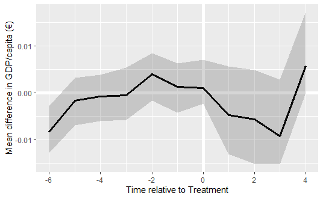

```r
# pdf(file="images/prelim_results/placeboATT.pdf",
#     width = 4, height = 3)
plot(out_n2, #ylim = c(-2000, 2000),
     xlim = c(-8, 4),
     main = "",
     ylab = "Mean difference in GDP/capita (€)")
```

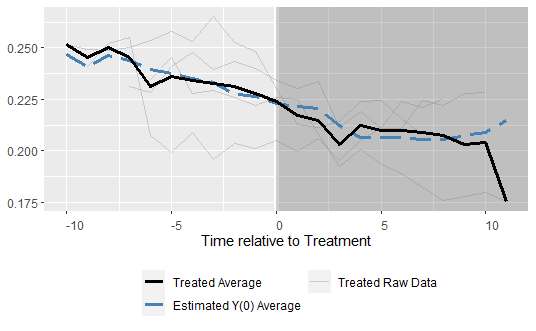

```r
# dev.off()

# plot all data:
plot(out_n2, type = "counterfactual",
     raw = "all", main = "") # Why the final dip
```

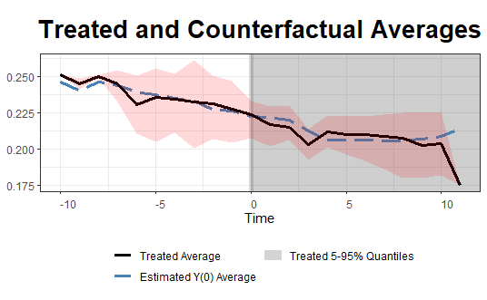

```r
# We can also add two 5 to 95% quantile bands of the treated and control outcomes as references to make sure the estimated counterfactuals are not results of severe extrapolations.

plot(out_n2, type = "counterfactual",
     raw = "band", xlab = "Time",
     # ylim = c(-5,35),
     theme.bw = TRUE)
```

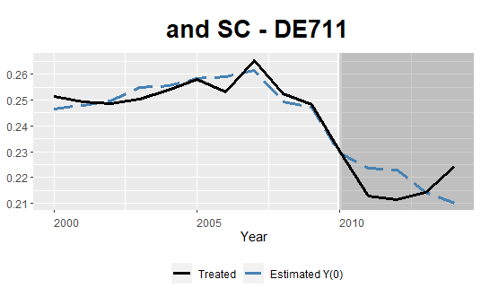

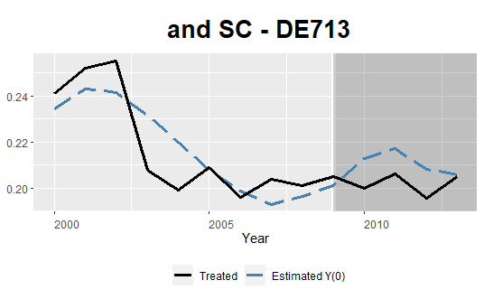

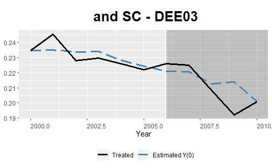

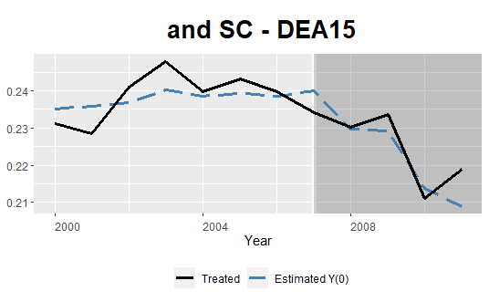

```r
for (i in n3_dta[n3_dta$treated_uz == TRUE, ]$geo %>% unique()){
  # pdf(file=paste0("images/prelim_results/ind_placebo",
  #                 "_",  i, ".pdf"),
  #   width = 3.5, height = 3.1)
  plot(out_n2, type = "counterfactual", id = i,
       xlim = c(2000, n3_dta[n3_dta$geo == i,
                                           ]$year_announced[1]-1),
       main = paste0(
         # n3_dta[n3_dta$geo == i,]$LEZ[1],
                       " and SC", " - ",
                     n3_dta[n3_dta$geo == i,]$geo[1]),
       sub = "Pre-intervention placebo of 3 years",
       xlab = "Year")
  # dev.off()
}
```

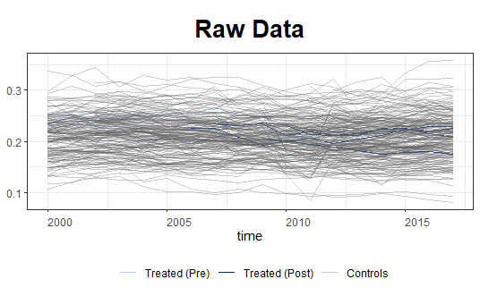

```r
plot(out_n2, type = "raw", theme.bw = TRUE)
```

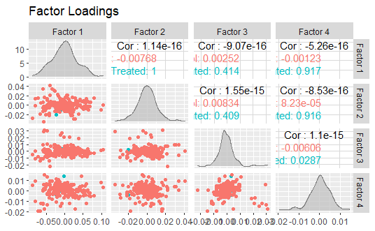

```r
plot(out_n2, type = "loadings")
```

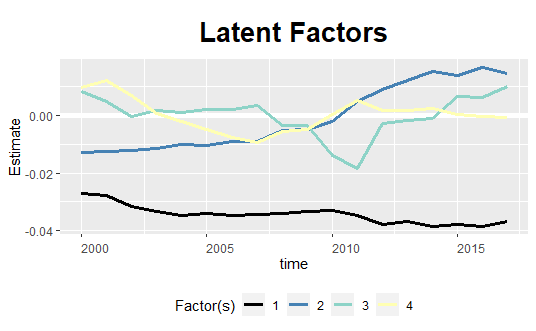

```r
plot(out_n2, type = "factors")
```

```r
out_n2$lambda.tr
```

```
                r1           r2          r3            r4
DE711 -0.022588840 -0.020079180 0.002591896 -0.0044600303
DE713 -0.001433802 -0.003891104 0.003061528  0.0137817909
DEA15 -0.010461208 -0.010910031 0.004113959 -0.0003604354
DEE03 -0.005795016 -0.006874529 0.003499988  0.0055395172
```

Now that I have restricted the sameple to those cities which I can create a Synthetic control y do the results:

#### 4. Outcome

```r
n3_dta <- main_dta %>%

  # Treated that have good synths or controls
  filter(geo %in% out_n2$id.tr | !treated_uz ) %>%

  filter(treated_uz | contr_restr_60km) %>%
  # filter(country == "DE") %>%
  # filter(country %in% c("DE",
  #                       "NL", "BE", "AT",
  #                       "SE", "NO", "FI"
  #                       )) %>%
  filter(!(country %in% c("EL", "ES", "IT", "PT", "PL", "TR")))
  # filter(!(geo %in% not_optimal_treated)) %>%

# Minimum pop density in sample and in treated
n3_dta$pop_km2 %>% summary()
```

```
   Min. 1st Qu.  Median    Mean 3rd Qu.    Max.    NA's
    1.1    49.1    92.5   423.5   276.8 10109.5    2203
```

```r
n3_dta[n3_dta$treated_uz == TRUE, ]$pop_km2 %>% summary()
```

```
   Min. 1st Qu.  Median    Mean 3rd Qu.    Max.    NA's
   1129    1152    1395    1633    1793    2855       8
```

```r
n3_dta <- n3_dta %>%
  filter(pop_km2 > 100) %>% #avoid rural areas
  group_by(geo) %>%
  # filter(
  #   mean(gdp_eur_hab, na.rm = TRUE) < 75000,
  #   mean(gdp_eur_hab, na.rm = TRUE) > 15000
  # ) %>%
    filter(
    mean(gva_rate_local_trade, na.rm = TRUE) < 0.3,
    mean(gva_rate_local_trade, na.rm = TRUE) > 0.10,
  ) %>%
  ungroup()

out_n2 <- gsynth(gva_rate_local_trade ~ is_announced,
               data = n3_dta,
               index = c("geo","time"),
               na.rm = TRUE, # remove NA
               force = "time", # unit or time fixed effects or both?
               # CV = TRUE,
               r = c(0, 4), # an integer specifying the number of factors. If CV = TRUE, the cross validation procedure will select the optimal number of factors from r to 5.
               se = TRUE,
               EM = TRUE, # Gobillon and Magnac (takes a lot of time)
               inference = "parametric",
               # estimator = "mc",
               nboots = 300,  #500
               parallel = TRUE, cores = 5, # if do parallel and how many cores
               min.T0 = 6) # Has to be larger than r.max+1
```

[output not shown]

```r
out_n2 %>% print()
```

```
Call:
gsynth.formula(formula = gva_rate_local_trade ~ is_announced,
    data = n3_dta, na.rm = TRUE, index = c("geo", "time"),
    force = "time", r = c(0, 4), EM = TRUE, se = TRUE,
    nboots = 300, inference = "parametric", parallel = TRUE,
    cores = 5, min.T0 = 6)

Average Treatment Effect on the Treated:
    ATT.avg     S.E.  CI.lower CI.upper p.value
 -0.0008672 0.003279 -0.008495 0.003882    0.46

   ~ by Period (including Pre-treatment Periods):
           ATT     S.E.  CI.lower  CI.upper p.value n.Treated
-10 -0.0087080 0.002831 -0.014565 -0.003737 0.00000         0
-9  -0.0017206 0.002806 -0.006971  0.003746 0.58000         0
-8  -0.0010102 0.002543 -0.005274  0.004238 0.79333         0
-7  -0.0009858 0.002803 -0.006607  0.004314 0.71333         0
-6   0.0042103 0.003158 -0.002747  0.009594 0.29333         0
-5   0.0025209 0.003115 -0.003509  0.008670 0.42667         0
-4   0.0038342 0.003027 -0.001231  0.010245 0.12000         0
-3  -0.0002600 0.002567 -0.005166  0.004620 0.90667         0
-2  -0.0022749 0.003151 -0.008800  0.003311 0.32667         0
-1  -0.0085585 0.002921 -0.014309 -0.002656 0.01333         0
0    0.0059984 0.002187  0.001823  0.010217 0.01333         0
1    0.0037270 0.005177 -0.006797  0.013620 0.56000         4
2    0.0016381 0.005270 -0.008664  0.011045 0.86000         4
3    0.0007742 0.005529 -0.011699  0.010028 0.95333         4
4    0.0034786 0.006271 -0.009177  0.013480 0.76667         3
5   -0.0035719 0.004761 -0.015084  0.002922 0.19333         2
6   -0.0039302 0.005427 -0.016412  0.004925 0.23333         2
7   -0.0373318 0.007670 -0.055027 -0.025337 0.00000         1
```

```r
out_n2$Nco
```

```
[1] 213
```

```r
out_n2$Ntr
```

```
[1] 4
```

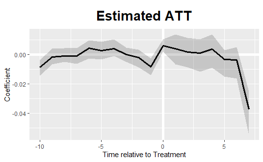

```r
# pdf(file="images/prelim_results/realATT.pdf",
#     width = 3.5, height = 3.1)
plot(out_n2) # ylim = c(-3500, 3500))
```

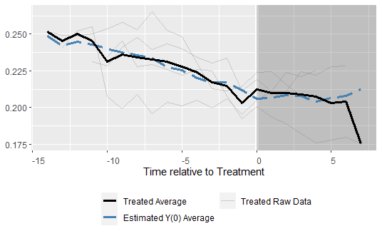

```r
# dev.off()

# plot all data:
plot(out_n2, type = "counterfactual",
     raw = "all", main="") # Why the final dip
```

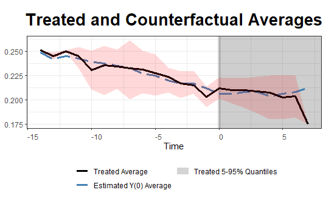

```r
# We can also add two 5 to 95% quantile bands of the treated and control outcomes as references to make sure the estimated counterfactuals are not results of severe extrapolations.

plot(out_n2, type = "counterfactual",
     raw = "band", xlab = "Time",
     # ylim = c(-5,35),
     theme.bw = TRUE)
```

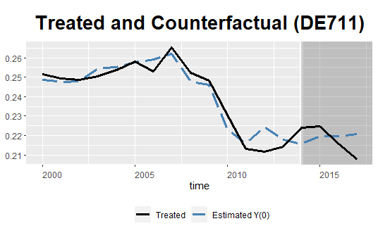

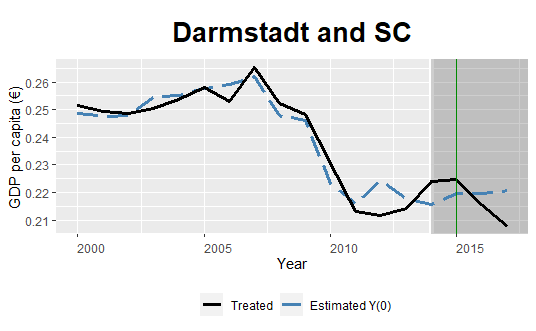

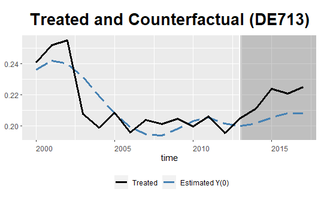

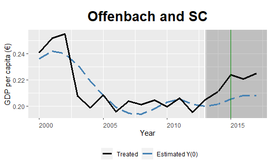

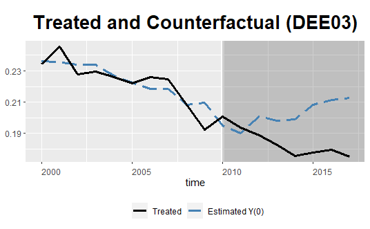

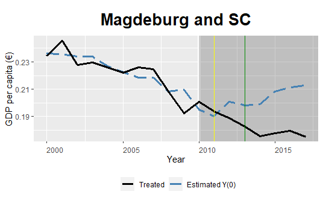

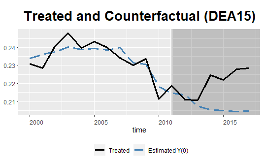

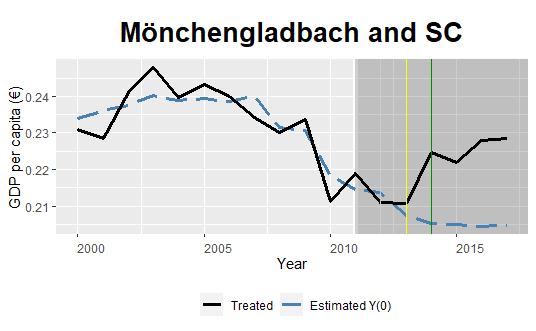

```r
for (i in n3_dta[n3_dta$treated_uz == TRUE, ]$geo %>% unique()){
  if (i %in% out_n2$id.tr){
    temp <- plot(out_n2, type = "counterfactual", id = i)
    # pdf(file=paste0("images/prelim_results/ind_real",
    #               "_",  i, ".pdf"),
    # width = 3.5, height = 3.1)
    print(temp +
            geom_vline(xintercept = n3_dta[n3_dta$geo == i,
                                           ]$year_announced[1],
                       color = "grey80") +
            geom_vline(xintercept = n3_dta[n3_dta$geo == i,
                                           ]$year_stage1[1],
                       color = "red1") +
            geom_vline(xintercept = n3_dta[n3_dta$geo == i,
                                           ]$year_stage2[1],
                       color = "yellow1") +
            geom_vline(xintercept = n3_dta[n3_dta$geo == i,
                                           ]$year_stage3[1],
                       color = "green4") +
      labs(
        title = paste0(n3_dta[n3_dta$geo == i,]$LEZ[1],
                       " and SC"),
        y = "GDP per capita (€)",
        x  = "Year"
      )
    )
    # dev.off()
  }
}
```

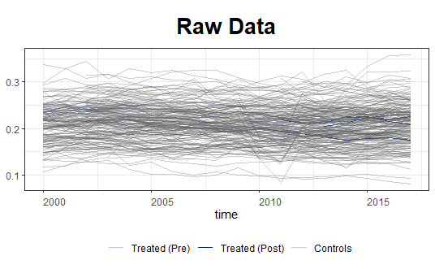

```r
plot(out_n2, type = "raw", theme.bw = TRUE)
```

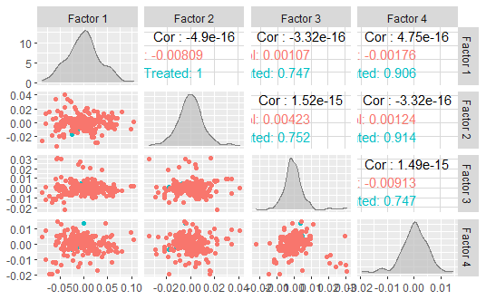

```r
# pdf(file="images/prelim_results/f_loadings.pdf",
#     width = 5, height = 4)
plot(out_n2, type = "loadings", main = "")
```

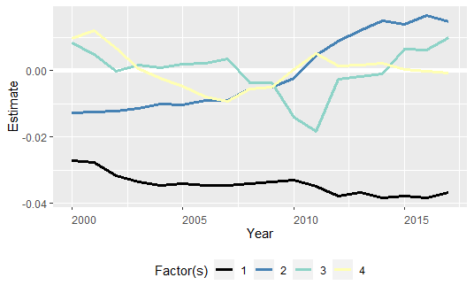

```r
# dev.off()


# pdf(file="images/prelim_results/factors_time.pdf",
#     width = 4, height = 3)
fact_ggplot <- plot(out_n2, type = "factors",
                    main = "",
                    xlab = "Year")
```

```r
# fact_ggplot +
#   labs(title = "",
#        x = "Year")
# dev.off()
```

#### 4. (extended)

##### Support for predictors

```
Not a data frame.
```

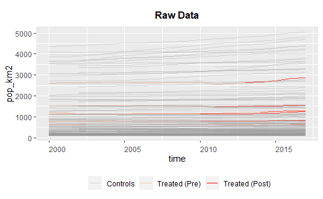

```r
panelView(pop_km2 ~ is_announced, data = n3_dta,
          index = c("geo","time"), type = "outcome")
```

```
Not a data frame.
```

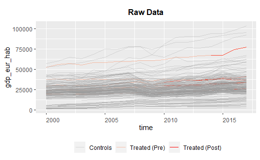

```r
panelView(gdp_eur_hab ~ is_announced, data = n3_dta,
          index = c("geo","time"), type = "outcome")
```

```
Not a data frame.
```

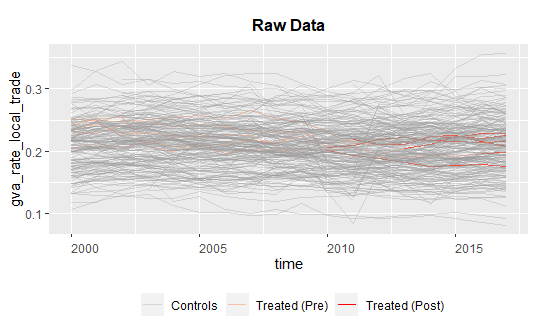

```r
panelView(gva_rate_local_trade ~ is_announced, data = n3_dta,
          index = c("geo","time"), type = "outcome")
```

#### Factor analysis

```r
# Know the donor pool of each treated:
weights_result <- out_n2$wgt.implied %>%
  as_tibble(rownames = "NUTS_ID")

# temp <- n2_dta %>%
#   left_join(weights_result, by = c("geo" = "NUTS_ID")) %>%
#   # filter(treated_uz == TRUE)
#   filter(geo == "DE30" | !(is.na(DE30))) %>%
#   filter(time >= 2000 & time <= 2008) %>%
#   group_by(geo == "DE30", time) %>%
#   mutate(DE30 = DE30-mean(DE30)/sd(DE30)) %>%
#   mutate(DE30 = ifelse(geo == "DE30", mean(DE30, na.rm = TRUE), DE30)) %>%
#   dplyr::summarise(mean_unem = weighted.mean(gdp_eur_hab,
#                                              DE30, na.rm = TRUE))
# # %>%
# #   pivot_wider(id_cols = time, names_from = `geo == "DE30"`,
# #               values_from = mean_unem)
#
#   select(geo, time, DE30, unempR_T); temp
# temp
# temp %>%
#   ggplot() +
#   geom_line(aes(x= time, y = mean_unem, color = `geo == "DE30"`))
#
# out_n2$lambda.co # estimated loadings of each factor
out_n2$lambda.tr # estimated loadings of each factor
```

[output not shown]

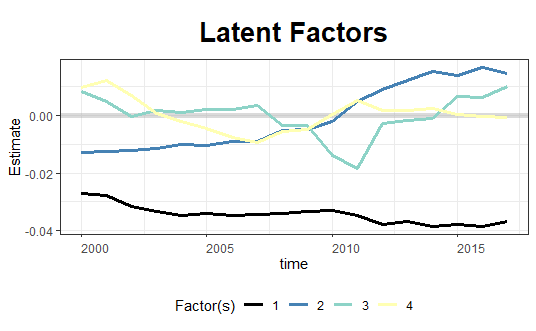

```r
# out_n2$wgt.implied
#
# MASS::ginv(t(as.matrix(out_n2$lambda.tr)))
plot(out_n2, type = "factors", theme.bw = TRUE)
```

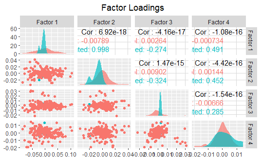

```r
plot(out_n2, type = "loadings")
```

Regarding factors’ evolution:

“Bearing in mind the caveat that estimated factors may not be directly interpretable because they are, at best, linear transformations of the true factors, we find that the estimated factors shown in this figure are meaningful. The first factor captures the sharp increase in turnout in the southern states because of the 1965 Voting Rights Act that removed Jim Crow laws, such as poll taxes or literacy tests, that suppressed turnout.”

Regarding factor loadings:

“Another reassuring finding shown by Figure 3b is that the estimated factor loadings of the nine treated units mostly lie in the convex hull of those of the control units, which indicates that the treated counterfactuals are produced mostly by more reliable interpolations instead of extrapolations.” (paper Gsynth)